# hmp2MetaViz-checklist

Domenick Braccia

August 28, 2018

This document will address all of the items listed on the slack thread posted on Wednesday July 18th between Domenick and Justin. These items will be listed as subheadings below

## Loading libraries

```r
library(metagenomeSeq)
library(ggplot2)
```

## Loading data

The code in the next chunck will use `source()` to run two scripts for generation of the pilot and biposy mrexp objects. For consistensy, the code used to generate these mrexp objects is nearly identical to code sent by Justin. Filtering and normalization is performed within the mrexp generation scripts as well.

**NOTE**: sourcing these two scripts will add two objects to the environment: `pilot_mrexp` and `biopsy_mrexp` which will be used later in this document.

```r
source("pilot-mrexp-generation.R")
source("biopsy-mrexp-generation.R")
```

# Slack Items

The following items were listed on Justin & Domenick’s slack conversation on July 18th, 2018 as things that needed to be completed:

1. **DONE** Table 1: Look at eachother’s code and results for the two features found using fitFeatureModel
2. **DONE** Figure 3: Double check feature using metagenomeSeq with Metaviz - Justin probably provide workspace
3. **DONE** Move appendix B from dissertation into Supplementary Materials
4. Check all Supplementary Materials
- Appendix B, Table 3
- **DONE** Appendix B, Table 4
5. Figure 4: Double check feature using fitZig with Metaviz
6. **DONE** Figure 5: Domenick send results and analysis that are similar - Justin send code and metaviz workspace

Some of these items have already been completed, while some of them will be addressed in this document. Also - some items may be out of order.

## 4. Checking All Supplementary material

### Appendix B, Table 4: Differential Abundance Testing Results for Pair-Wise comparison of CD, UC, nonIBD

After performing pair-wise differential abundance testing, I found that many of the same significant features turned up. However, my calculations seemed to yield more strict adjusted p-values than Justin’s calculations. The code blow will generate these results tables for further inspection.

```r
### initializing some variables

# setting the feature order
feature_order <- colnames(fData(biopsy_mrexp))

# finding indicies for groups to be compared
uc_and_nonIBD <- which(pData(biopsy_mrexp)$diagnosis %in% c("nonIBD", "UC"))
cd_and_nonIBD <- which(pData(biopsy_mrexp)$diagnosis %in% c("nonIBD", "CD"))
uc_and_cd <- which(pData(biopsy_mrexp)$diagnosis %in% c("CD", "UC"))

### initializing the run_fitFitFeatMod function

run_fitFeatMod <- function(mrexp_obj, tax, groups) {

  # aggregating the counts to appropriate level for analysis
  agg_mrexp <- aggregateByTaxonomy(mrexp_obj, lvl = tax, featureOrder = feature_order)

  # set norm factors
  normFactors(agg_mrexp) <- normFactors(mrexp_obj)

  # subset the mrexp obj by diagnosis
  agg_groups_mrexp <- agg_mrexp[, which(pData(mrexp_obj)$diagnosis %in% groups)]
  agg_groups_prepmod <- pData(agg_mrexp[, which(pData(mrexp_obj)$diagnosis %in% groups)])$diagnosis

  # releveling the "pre" model matrix based on what groups are being compared
  if ("nonIBD" %in% groups) {
    relevel(agg_groups_prepmod, "nonIBD")
  } else (relevel(agg_groups_prepmod, "CD"))

  # set model matrix
  agg_groups_mod <- model.matrix(~agg_groups_prepmod)

  # run fitFeatureModel
  fit_feat_mod_results <- fitFeatureModel(agg_groups_mrexp, agg_groups_mod)

  # use MRcoefs() to extract results
  fit_feat_mod_MRcoefs <- MRcoefs(fit_feat_mod_results, number = 50) #change value for number to see more features
  fit_feat_mod_MRcoefs <- fit_feat_mod_MRcoefs[order(fit_feat_mod_MRcoefs$adjPvalues),]
  return(fit_feat_mod_MRcoefs)
}
```

#### Running `run_fitFeatMod` on all levels of taxonomy and all combinations of diagnoses. Species, genera, etc. with adjPvalue < 0.1 displayed.

```r
### UC vs. nonIBD
UC_nonIBD_species_res <- run_fitFeatMod(mrexp_obj = biopsy_mrexp, tax = "species", groups = c("UC", "nonIBD"))
subset(UC_nonIBD_species_res, adjPvalues < 0.1)
```

```
##              logFC        se      pvalues adjPvalues
## GX7Fr128  3.054368 0.7972816 0.0001276350 0.04913948
## UncO1674 -4.469588 1.3108836 0.0006505836 0.07601859
## Unc92642  2.578967 0.7735940 0.0008568431 0.07601859
## Unc91427 -1.853620 0.5457235 0.0006822139 0.07601859
## Unc04zvf  4.844131 1.4941233 0.0011864292 0.07612921
## Unc05mrd -2.381313 0.7504984 0.0015088528 0.08298690
## Unc02mpn  2.086549 0.6709937 0.0018731524 0.09014546
```

```r
UC_nonIBD_genus_res <- run_fitFeatMod(mrexp_obj = biopsy_mrexp, tax = "genus", groups = c("UC", "nonIBD"))
subset(UC_nonIBD_genus_res, adjPvalues < 0.1)
```

```
##                               logFC        se      pvalues adjPvalues
##  __Citrobacter             3.005659 0.7792223 0.0001146678 0.02109887
##  __Megasphaera            -2.595868 0.7650617 0.0006912722 0.05253754
##  __Dielma                  2.526711 0.7923204 0.0014276505 0.05253754
##  __Akkermansia            -2.350067 0.7362005 0.0014121488 0.05253754
##  __Erysipelatoclostridium  1.610475 0.4943257 0.0011223066 0.05253754
```

```r
UC_nonIBD_family_res <- run_fitFeatMod(mrexp_obj = biopsy_mrexp, tax = "family", groups = c("UC", "nonIBD"))
subset(UC_nonIBD_family_res, adjPvalues < 0.1)
```

```
## [1] logFC      se         pvalues    adjPvalues
## <0 rows> (or 0-length row.names)
```

```r
UC_nonIBD_order_res <- run_fitFeatMod(mrexp_obj = biopsy_mrexp, tax = "order", groups = c("UC", "nonIBD"))
subset(UC_nonIBD_order_res, adjPvalues < 0.1)
```

```
##                           logFC        se      pvalues adjPvalues
##  __Verrucomicrobiales -2.344053 0.6989085 0.0007968796 0.03107831
```

```r
UC_nonIBD_class_res <- run_fitFeatMod(mrexp_obj = biopsy_mrexp, tax = "class", groups = c("UC", "nonIBD"))
subset(UC_nonIBD_class_res, adjPvalues < 0.1)
```

```
##                         logFC       se     pvalues adjPvalues
##  __Verrucomicrobiae -2.329069 0.717556 0.001171064 0.02810554
```

```r
UC_nonIBD_phylum_res <- run_fitFeatMod(mrexp_obj = biopsy_mrexp, tax = "phylum", groups = c("UC", "nonIBD"))
subset(UC_nonIBD_phylum_res, adjPvalues < 0.1)
```

```
##                        logFC        se     pvalues adjPvalues
##  __Verrucomicrobia -2.375142 0.7534036 0.001618514 0.01942217
```

```r
UC_nonIBD_kingdom_res <- run_fitFeatMod(mrexp_obj = biopsy_mrexp, tax = "kingdom", groups = c("UC", "nonIBD"))
subset(UC_nonIBD_kingdom_res, adjPvalues < 0.1)
```

```
## [1] logFC      se         pvalues    adjPvalues
## <0 rows> (or 0-length row.names)
```

```r
### CD vs. nonIBD
CD_nonIBD_species_res <- run_fitFeatMod(mrexp_obj = biopsy_mrexp, tax = "species", groups = c("CD", "nonIBD"))
subset(CD_nonIBD_species_res, adjPvalues < 0.1)
```

```
##              logFC        se      pvalues adjPvalues
## Gt8Me241 -3.435347 0.8723273 8.211576e-05 0.01472546
## UncO6361 -1.520641 0.3942454 1.147438e-04 0.01472546
## Unc01ie9 -1.441829 0.4553825 1.544478e-03 0.06606934
## Unc21180 -2.507378 0.8225044 2.300119e-03 0.07366193
## GX7Fr128 -1.606448 0.5350548 2.678616e-03 0.07366193
```

```r
CD_nonIBD_genus_res <- run_fitFeatMod(mrexp_obj = biopsy_mrexp, tax = "genus", groups = c("CD", "nonIBD"))
subset(CD_nonIBD_genus_res, adjPvalues < 0.1)
```

```
##                                      logFC        se      pvalues
##  __Coprobacter                  -3.3814607 0.8826871 1.276904e-04
##  __Lachnospiraceae_ND3007_group  1.3584991 0.3454752 8.415026e-05
##  __Ruminococcus_1                1.7493486 0.5188441 7.472570e-04
##  __Fusobacterium                -1.5101585 0.4479979 7.492158e-04
##  __Subdoligranulum               0.9831133 0.2917302 7.518466e-04
##  __Citrobacter                  -1.5917025 0.5354416 2.952012e-03
##                                 adjPvalues
##  __Coprobacter                  0.01174751
##  __Lachnospiraceae_ND3007_group 0.01174751
##  __Ruminococcus_1               0.02766796
##  __Fusobacterium                0.02766796
##  __Subdoligranulum              0.02766796
##  __Citrobacter                  0.07759575
```

```r
CD_nonIBD_family_res <- run_fitFeatMod(mrexp_obj = biopsy_mrexp, tax = "family", groups = c("CD", "nonIBD"))
subset(CD_nonIBD_family_res, adjPvalues < 0.1)
```

```
##                         logFC        se      pvalues adjPvalues
##  __Fusobacteriaceae -1.475013 0.4479308 0.0009914248 0.06543404
```

```r
CD_nonIBD_order_res <- run_fitFeatMod(mrexp_obj = biopsy_mrexp, tax = "order", groups = c("CD", "nonIBD"))
subset(CD_nonIBD_order_res, adjPvalues < 0.1)
```

```
##                        logFC        se     pvalues adjPvalues
##  __Fusobacteriales -1.417281 0.4458438 0.001478487 0.05766097
```

```r
CD_nonIBD_class_res <- run_fitFeatMod(mrexp_obj = biopsy_mrexp, tax = "class", groups = c("CD", "nonIBD"))
subset(CD_nonIBD_class_res, adjPvalues < 0.1)
```

```
##                      logFC        se     pvalues adjPvalues
##  __Fusobacteriia -1.423696 0.4470616 0.001449732 0.03479356
```

```r
CD_nonIBD_phylum_res <- run_fitFeatMod(mrexp_obj = biopsy_mrexp, tax = "phylum", groups = c("CD", "nonIBD"))
subset(CD_nonIBD_phylum_res, adjPvalues < 0.1)
```

```
##                      logFC        se     pvalues adjPvalues
##  __Fusobacteria -1.4240319 0.4491183 0.001520577 0.01824693
##  __Tenericutes   0.3627412 0.1432172 0.011315409 0.06789246
```

```r
CD_nonIBD_kingdom_res <- run_fitFeatMod(mrexp_obj = biopsy_mrexp, tax = "kingdom", groups = c("CD", "nonIBD"))
subset(CD_nonIBD_kingdom_res, adjPvalues < 0.1)
```

```
## [1] logFC      se         pvalues    adjPvalues
## <0 rows> (or 0-length row.names)
```

```r
### CD vs. UC
CD_UC_species_res <- run_fitFeatMod(mrexp_obj = biopsy_mrexp, tax = "species", groups = c("CD", "UC"))
subset(CD_UC_species_res, adjPvalues < 0.1)
```

```
## [1] logFC      se         pvalues    adjPvalues
## <0 rows> (or 0-length row.names)
```

```r
CD_UC_genus_res <- run_fitFeatMod(mrexp_obj = biopsy_mrexp, tax = "genus", groups = c("CD", "UC"))
subset(CD_UC_genus_res, adjPvalues < 0.1)
```

```
## [1] logFC      se         pvalues    adjPvalues
## <0 rows> (or 0-length row.names)
```

```r
CD_UC_family_res <- run_fitFeatMod(mrexp_obj = biopsy_mrexp, tax = "family", groups = c("CD", "UC"))
subset(CD_UC_family_res, adjPvalues < 0.1)
```

```
##                        logFC        se     pvalues adjPvalues
##  __Veillonellaceae -1.091468 0.3386719 0.001269494 0.08378663
```

```r
CD_UC_order_res <- run_fitFeatMod(mrexp_obj = biopsy_mrexp, tax = "order", groups = c("CD", "UC"))
subset(CD_UC_order_res, adjPvalues < 0.1)
```

```
## [1] logFC      se         pvalues    adjPvalues
## <0 rows> (or 0-length row.names)
```

```r
CD_UC_class_res <- run_fitFeatMod(mrexp_obj = biopsy_mrexp, tax = "class", groups = c("CD", "UC"))
subset(CD_UC_class_res, adjPvalues < 0.1)
```

```
## [1] logFC      se         pvalues    adjPvalues
## <0 rows> (or 0-length row.names)
```

```r
CD_UC_phylum_res <- run_fitFeatMod(mrexp_obj = biopsy_mrexp, tax = "phylum", groups = c("CD", "UC"))
subset(CD_UC_phylum_res, adjPvalues < 0.1)
```

```
## [1] logFC      se         pvalues    adjPvalues
## <0 rows> (or 0-length row.names)
```

```r
CD_UC_kingdom_res <- run_fitFeatMod(mrexp_obj = biopsy_mrexp, tax = "kingdom", groups = c("CD", "UC"))
subset(CD_UC_kingdom_res, adjPvalues < 0.1)
```

```
## [1] logFC      se         pvalues    adjPvalues
## <0 rows> (or 0-length row.names)
```

## 1. Checking results from Table 1

This section confirms the results presented in table 1 of the manuscript with the code below.

```r
head(run_fitFeatMod(mrexp_obj = pilot_mrexp, tax = "species", groups = c("CD", "UC")), 2)
```

```
##               logFC        se      pvalues   adjPvalues
## s__:369227 1.864583 0.4311937 1.530614e-05 0.0007346945
## s__:363232 1.193035 0.2754150 1.479140e-05 0.0007346945
```

## 6. Figure 5 results confirmed with metagenomeSeq

The following section is meant to confirm the figures generated by MetaViz using metagenomeSeq

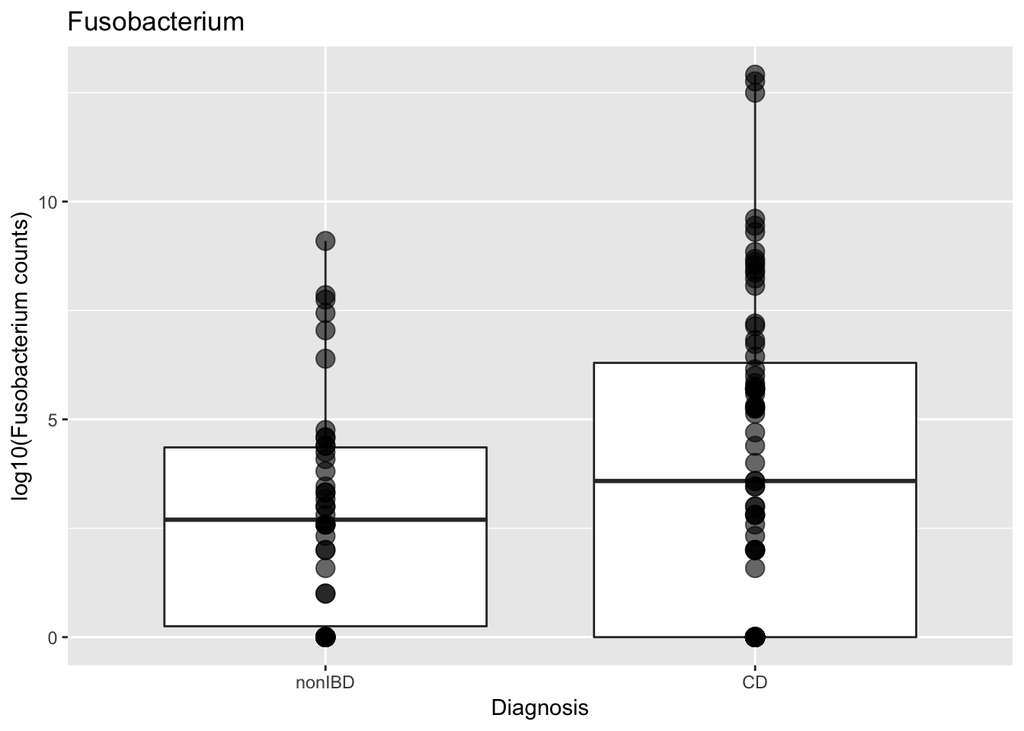

```r
# CD vs. nonIBD
biopsy_mrexp_genus <- aggTax(biopsy_mrexp, lvl = "genus")
cd_and_nonIBD_biopsy_mrexp_genus <- biopsy_mrexp_genus[,cd_and_nonIBD]
cd_and_nonIBD_biopsy_counts_genus <- MRcounts(cd_and_nonIBD_biopsy_mrexp_genus)

## Fusobacterium
fuso_counts <- log2(cd_and_nonIBD_biopsy_counts_genus[" __Fusobacterium",])
fuso_counts[is.infinite(fuso_counts)] <- 0
CD_nonIBD_diagnosis <- relevel(cd_and_nonIBD_biopsy_mrexp_genus$diagnosis, ref = "nonIBD") #only needs to be done once
fuso_boxplot <- as.data.frame(cbind(as.numeric(fuso_counts), as.factor(CD_nonIBD_diagnosis)))

ggplot(fuso_boxplot, aes(x = CD_nonIBD_diagnosis, y = fuso_counts)) +
  geom_boxplot() +
  geom_point(alpha = 0.6, size = 4) +
  ggtitle("Fusobacterium") + xlab("Diagnosis") + ylab("log10(Fusobacterium counts)")
```

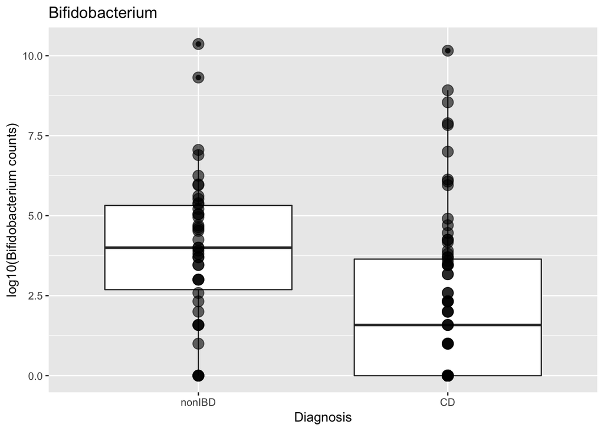

```r
## Bifidobacterium
bifido_counts <- log2(cd_and_nonIBD_biopsy_counts_genus[" __Bifidobacterium",])
bifido_counts[is.infinite(bifido_counts)] <- 0
bifido_boxplot <- as.data.frame(cbind(as.numeric(bifido_counts), as.factor(CD_nonIBD_diagnosis)))

ggplot(bifido_boxplot, aes(x = CD_nonIBD_diagnosis, y = bifido_counts)) +
  geom_boxplot() +
  geom_point(alpha = 0.6, size = 4) +
  ggtitle("Bifidobacterium") + xlab("Diagnosis") + ylab("log10(Bifidobacterium counts)")
```

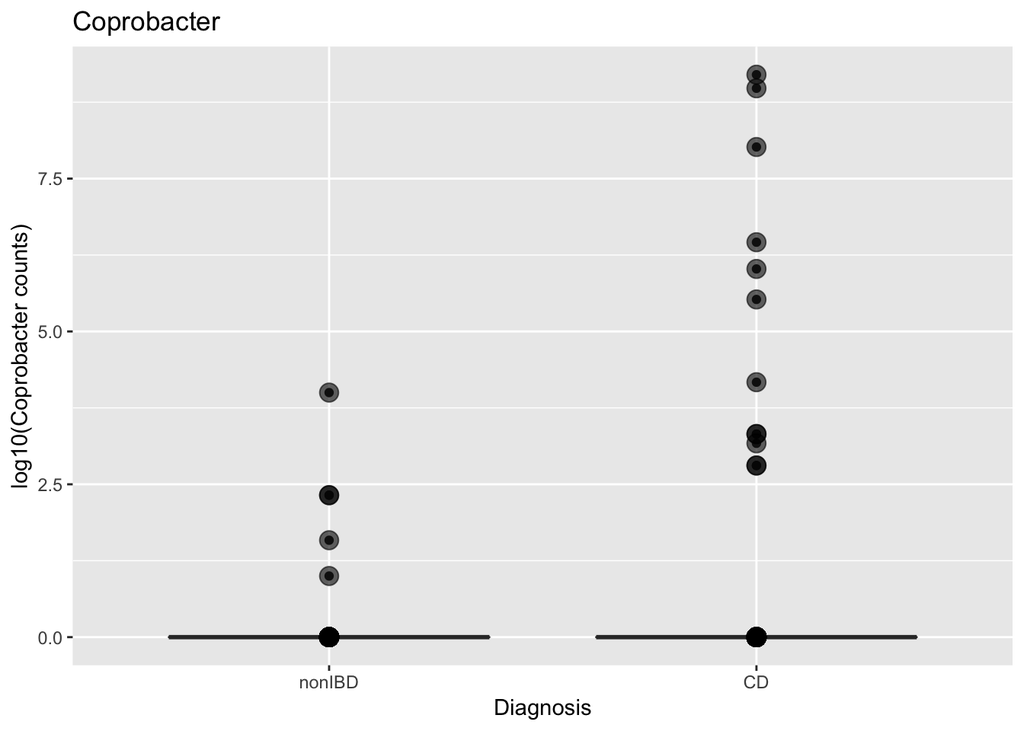

```r
## Coprobacter
copro_counts <- log2(cd_and_nonIBD_biopsy_counts_genus[" __Coprobacter",])
copro_counts[is.infinite(copro_counts)] <- 0
copro_boxplot <- as.data.frame(cbind(as.numeric(copro_counts), as.factor(CD_nonIBD_diagnosis)))

ggplot(copro_boxplot, aes(x = CD_nonIBD_diagnosis, y = copro_counts)) +
  geom_boxplot() +
  geom_point(alpha = 0.6, size = 4) +
  ggtitle("Coprobacter") + xlab("Diagnosis") + ylab("log10(Coprobacter counts)")
```

## 2. Figure 3: Double check feature using metagenomeSeq with Metaviz

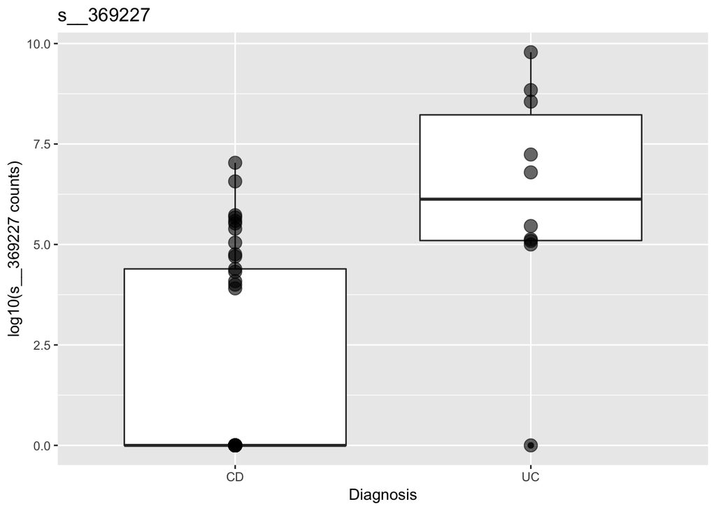

```r
pilot_mrexp_species <- aggTax(pilot_mrexp, lvl = "species")
pilot_counts_genus <- MRcounts(pilot_mrexp_species)

s__369227_counts <- log2(pilot_counts_genus["s__:369227",])
s__369227_counts[is.infinite(s__369227_counts)] <- 0
pilot_diagnosis <- relevel(pilot_mrexp$diagnosis, ref = "CD")
s__369227_boxplot <- as.data.frame(s__369227_counts)
s__369227_boxplot$pilot_diagnosis <- pilot_diagnosis

ggplot(s__369227_boxplot, aes(x = pilot_diagnosis, y = s__369227_counts)) +
  geom_boxplot() +
  geom_point(alpha = 0.6, size = 4) +
  ggtitle("s__369227") + xlab("Diagnosis") + ylab("log10(s__369227 counts)")
```